# Divvy Google DA Capstone

DA Cert

2023-01-12

### Uploading raw data

```r
library(tidyverse)
library(lubridate)
```

```r
library(ggplot2)
q2_2019 <- read_csv("Divvy_Trips_2019_Q2.csv")
q3_2019 <- read_csv("Divvy_Trips_2019_Q2.csv")
q4_2019 <- read_csv("Divvy_Trips_2019_Q2.csv")
q1_2020 <- read_csv("Divvy_Trips_2020_Q1.csv")
```

### Wrangle and merging raw data

We need to merge the raw data before we begin our analysis. We start by renaming the columns to ensure that we can combine the raw data into a single file.

```r
colnames(q2_2019)
```

```
##  [1] "01 - Rental Details Rental ID"
##  [2] "01 - Rental Details Local Start Time"
##  [3] "01 - Rental Details Local End Time"
##  [4] "01 - Rental Details Bike ID"
##  [5] "01 - Rental Details Duration In Seconds Uncapped"
##  [6] "03 - Rental Start Station ID"
##  [7] "03 - Rental Start Station Name"
##  [8] "02 - Rental End Station ID"
##  [9] "02 - Rental End Station Name"
## [10] "User Type"
## [11] "Member Gender"
## [12] "05 - Member Details Member Birthday Year"
```

```r
colnames(q3_2019)
```

```
##  [1] "01 - Rental Details Rental ID"
##  [2] "01 - Rental Details Local Start Time"
##  [3] "01 - Rental Details Local End Time"
##  [4] "01 - Rental Details Bike ID"
##  [5] "01 - Rental Details Duration In Seconds Uncapped"
##  [6] "03 - Rental Start Station ID"
##  [7] "03 - Rental Start Station Name"
##  [8] "02 - Rental End Station ID"
##  [9] "02 - Rental End Station Name"
## [10] "User Type"
## [11] "Member Gender"
## [12] "05 - Member Details Member Birthday Year"
```

```r
colnames(q4_2019)
```

```
##  [1] "01 - Rental Details Rental ID"
##  [2] "01 - Rental Details Local Start Time"
##  [3] "01 - Rental Details Local End Time"
##  [4] "01 - Rental Details Bike ID"
##  [5] "01 - Rental Details Duration In Seconds Uncapped"
##  [6] "03 - Rental Start Station ID"
##  [7] "03 - Rental Start Station Name"
##  [8] "02 - Rental End Station ID"
##  [9] "02 - Rental End Station Name"
## [10] "User Type"
## [11] "Member Gender"
## [12] "05 - Member Details Member Birthday Year"
```

```r
colnames(q1_2020)
```

```
##  [1] "ride_id"            "rideable_type"      "started_at"
##  [4] "ended_at"           "start_station_name" "start_station_id"
##  [7] "end_station_name"   "end_station_id"     "start_lat"
## [10] "start_lng"          "end_lat"            "end_lng"
## [13] "member_casual"
```

```r
(q2_2019 <- rename(q2_2019
                   ,ride_id = "01 - Rental Details Rental ID"
                   ,rideable_type = "01 - Rental Details Bike ID"
                   ,started_at = "01 - Rental Details Local Start Time"
                   ,ended_at = "01 - Rental Details Local End Time"
                   ,start_station_name = "03 - Rental Start Station Name"
                   ,start_station_id = "03 - Rental Start Station ID"
                   ,end_station_name = "02 - Rental End Station Name"
                   ,end_station_id = "02 - Rental End Station ID"
                   ,member_casual = "User Type"))
```

```
## # A tibble: 1,108,163 × 12
##     ride_id started_at          ended_at            rideable_t…¹ 01 - …² start…³
##       <dbl> <dttm>              <dttm>                     <dbl>   <dbl>   <dbl>
##  1 22178529 2019-04-01 00:02:22 2019-04-01 00:09:48         6251     446      81
##  2 22178530 2019-04-01 00:03:02 2019-04-01 00:20:30         6226    1048     317
##  3 22178531 2019-04-01 00:11:07 2019-04-01 00:15:19         5649     252     283
##  4 22178532 2019-04-01 00:13:01 2019-04-01 00:18:58         4151     357      26
##  5 22178533 2019-04-01 00:19:26 2019-04-01 00:36:13         3270    1007     202
##  6 22178534 2019-04-01 00:19:39 2019-04-01 00:23:56         3123     257     420
##  7 22178535 2019-04-01 00:26:33 2019-04-01 00:35:41         6418     548     503
##  8 22178536 2019-04-01 00:29:48 2019-04-01 00:36:11         4513     383     260
##  9 22178537 2019-04-01 00:32:07 2019-04-01 01:07:44         3280    2137     211
## 10 22178538 2019-04-01 00:32:19 2019-04-01 01:07:39         5534    2120     211
## # … with 1,108,153 more rows, 6 more variables: start_station_name <chr>,
## #   end_station_id <dbl>, end_station_name <chr>, member_casual <chr>,
## #   `Member Gender` <chr>, `05 - Member Details Member Birthday Year` <dbl>,
## #   and abbreviated variable names ¹rideable_type,
## #   ²`01 - Rental Details Duration In Seconds Uncapped`, ³start_station_id
```

```r
(q3_2019 <- rename(q3_2019
                   ,ride_id = "01 - Rental Details Rental ID"
                   ,rideable_type = "01 - Rental Details Bike ID"
                   ,started_at = "01 - Rental Details Local Start Time"
                   ,ended_at = "01 - Rental Details Local End Time"
                   ,start_station_name = "03 - Rental Start Station Name"
                   ,start_station_id = "03 - Rental Start Station ID"
                   ,end_station_name = "02 - Rental End Station Name"
                   ,end_station_id = "02 - Rental End Station ID"
                   ,member_casual = "User Type"))
```

```
## # A tibble: 1,108,163 × 12
##     ride_id started_at          ended_at            rideable_t…¹ 01 - …² start…³
##       <dbl> <dttm>              <dttm>                     <dbl>   <dbl>   <dbl>
##  1 22178529 2019-04-01 00:02:22 2019-04-01 00:09:48         6251     446      81
##  2 22178530 2019-04-01 00:03:02 2019-04-01 00:20:30         6226    1048     317
##  3 22178531 2019-04-01 00:11:07 2019-04-01 00:15:19         5649     252     283
##  4 22178532 2019-04-01 00:13:01 2019-04-01 00:18:58         4151     357      26
##  5 22178533 2019-04-01 00:19:26 2019-04-01 00:36:13         3270    1007     202
##  6 22178534 2019-04-01 00:19:39 2019-04-01 00:23:56         3123     257     420
##  7 22178535 2019-04-01 00:26:33 2019-04-01 00:35:41         6418     548     503
##  8 22178536 2019-04-01 00:29:48 2019-04-01 00:36:11         4513     383     260
##  9 22178537 2019-04-01 00:32:07 2019-04-01 01:07:44         3280    2137     211
## 10 22178538 2019-04-01 00:32:19 2019-04-01 01:07:39         5534    2120     211
## # … with 1,108,153 more rows, 6 more variables: start_station_name <chr>,
## #   end_station_id <dbl>, end_station_name <chr>, member_casual <chr>,
## #   `Member Gender` <chr>, `05 - Member Details Member Birthday Year` <dbl>,
## #   and abbreviated variable names ¹rideable_type,
## #   ²`01 - Rental Details Duration In Seconds Uncapped`, ³start_station_id
```

```r
(q4_2019 <- rename(q4_2019
                   ,ride_id = "01 - Rental Details Rental ID"
                   ,rideable_type = "01 - Rental Details Bike ID"
                   ,started_at = "01 - Rental Details Local Start Time"
                   ,ended_at = "01 - Rental Details Local End Time"
                   ,start_station_name = "03 - Rental Start Station Name"
                   ,start_station_id = "03 - Rental Start Station ID"
                   ,end_station_name = "02 - Rental End Station Name"
                   ,end_station_id = "02 - Rental End Station ID"
                   ,member_casual = "User Type"))
```

```
## # A tibble: 1,108,163 × 12
##     ride_id started_at          ended_at            rideable_t…¹ 01 - …² start…³
##       <dbl> <dttm>              <dttm>                     <dbl>   <dbl>   <dbl>
##  1 22178529 2019-04-01 00:02:22 2019-04-01 00:09:48         6251     446      81
##  2 22178530 2019-04-01 00:03:02 2019-04-01 00:20:30         6226    1048     317
##  3 22178531 2019-04-01 00:11:07 2019-04-01 00:15:19         5649     252     283
##  4 22178532 2019-04-01 00:13:01 2019-04-01 00:18:58         4151     357      26
##  5 22178533 2019-04-01 00:19:26 2019-04-01 00:36:13         3270    1007     202
##  6 22178534 2019-04-01 00:19:39 2019-04-01 00:23:56         3123     257     420
##  7 22178535 2019-04-01 00:26:33 2019-04-01 00:35:41         6418     548     503
##  8 22178536 2019-04-01 00:29:48 2019-04-01 00:36:11         4513     383     260
##  9 22178537 2019-04-01 00:32:07 2019-04-01 01:07:44         3280    2137     211
## 10 22178538 2019-04-01 00:32:19 2019-04-01 01:07:39         5534    2120     211
## # … with 1,108,153 more rows, 6 more variables: start_station_name <chr>,
## #   end_station_id <dbl>, end_station_name <chr>, member_casual <chr>,
## #   `Member Gender` <chr>, `05 - Member Details Member Birthday Year` <dbl>,
## #   and abbreviated variable names ¹rideable_type,
## #   ²`01 - Rental Details Duration In Seconds Uncapped`, ³start_station_id
```

### Inspect the dataframes and look for incongruencies

As the we are looking to combine the files together, we have to ensure that they are of the same data types so that they can stack correctly.

```r
str(q2_2019)
```

```
## spc_tbl_ [1,108,163 × 12] (S3: spec_tbl_df/tbl_df/tbl/data.frame)
##  $ ride_id                                         : num [1:1108163] 22178529 22178530 22178531 22178532 22178533 ...
##  $ started_at                                      : POSIXct[1:1108163], format: "2019-04-01 00:02:22" "2019-04-01 00:03:02" ...
##  $ ended_at                                        : POSIXct[1:1108163], format: "2019-04-01 00:09:48" "2019-04-01 00:20:30" ...
##  $ rideable_type                                   : num [1:1108163] 6251 6226 5649 4151 3270 ...
##  $ 01 - Rental Details Duration In Seconds Uncapped: num [1:1108163] 446 1048 252 357 1007 ...
##  $ start_station_id                                : num [1:1108163] 81 317 283 26 202 420 503 260 211 211 ...
##  $ start_station_name                              : chr [1:1108163] "Daley Center Plaza" "Wood St & Taylor St" "LaSalle St & Jackson Blvd" "McClurg Ct & Illinois St" ...
##  $ end_station_id                                  : num [1:1108163] 56 59 174 133 129 426 500 499 211 211 ...
##  $ end_station_name                                : chr [1:1108163] "Desplaines St & Kinzie St" "Wabash Ave & Roosevelt Rd" "Canal St & Madison St" "Kingsbury St & Kinzie St" ...
##  $ member_casual                                   : chr [1:1108163] "Subscriber" "Subscriber" "Subscriber" "Subscriber" ...
##  $ Member Gender                                   : chr [1:1108163] "Male" "Female" "Male" "Male" ...
##  $ 05 - Member Details Member Birthday Year        : num [1:1108163] 1975 1984 1990 1993 1992 ...
##  - attr(*, "spec")=
##   .. cols(
##   ..   `01 - Rental Details Rental ID` = col_double(),
##   ..   `01 - Rental Details Local Start Time` = col_datetime(format = ""),
##   ..   `01 - Rental Details Local End Time` = col_datetime(format = ""),
##   ..   `01 - Rental Details Bike ID` = col_double(),
##   ..   `01 - Rental Details Duration In Seconds Uncapped` = col_number(),
##   ..   `03 - Rental Start Station ID` = col_double(),
##   ..   `03 - Rental Start Station Name` = col_character(),
##   ..   `02 - Rental End Station ID` = col_double(),
##   ..   `02 - Rental End Station Name` = col_character(),
##   ..   `User Type` = col_character(),
##   ..   `Member Gender` = col_character(),
##   ..   `05 - Member Details Member Birthday Year` = col_double()
##   .. )
##  - attr(*, "problems")=<externalptr>
```

```r
str(q3_2019)
```

```
## spc_tbl_ [1,108,163 × 12] (S3: spec_tbl_df/tbl_df/tbl/data.frame)
##  $ ride_id                                         : num [1:1108163] 22178529 22178530 22178531 22178532 22178533 ...
##  $ started_at                                      : POSIXct[1:1108163], format: "2019-04-01 00:02:22" "2019-04-01 00:03:02" ...
##  $ ended_at                                        : POSIXct[1:1108163], format: "2019-04-01 00:09:48" "2019-04-01 00:20:30" ...
##  $ rideable_type                                   : num [1:1108163] 6251 6226 5649 4151 3270 ...
##  $ 01 - Rental Details Duration In Seconds Uncapped: num [1:1108163] 446 1048 252 357 1007 ...
##  $ start_station_id                                : num [1:1108163] 81 317 283 26 202 420 503 260 211 211 ...
##  $ start_station_name                              : chr [1:1108163] "Daley Center Plaza" "Wood St & Taylor St" "LaSalle St & Jackson Blvd" "McClurg Ct & Illinois St" ...
##  $ end_station_id                                  : num [1:1108163] 56 59 174 133 129 426 500 499 211 211 ...
##  $ end_station_name                                : chr [1:1108163] "Desplaines St & Kinzie St" "Wabash Ave & Roosevelt Rd" "Canal St & Madison St" "Kingsbury St & Kinzie St" ...
##  $ member_casual                                   : chr [1:1108163] "Subscriber" "Subscriber" "Subscriber" "Subscriber" ...
##  $ Member Gender                                   : chr [1:1108163] "Male" "Female" "Male" "Male" ...
##  $ 05 - Member Details Member Birthday Year        : num [1:1108163] 1975 1984 1990 1993 1992 ...
##  - attr(*, "spec")=
##   .. cols(
##   ..   `01 - Rental Details Rental ID` = col_double(),
##   ..   `01 - Rental Details Local Start Time` = col_datetime(format = ""),
##   ..   `01 - Rental Details Local End Time` = col_datetime(format = ""),
##   ..   `01 - Rental Details Bike ID` = col_double(),
##   ..   `01 - Rental Details Duration In Seconds Uncapped` = col_number(),
##   ..   `03 - Rental Start Station ID` = col_double(),
##   ..   `03 - Rental Start Station Name` = col_character(),
##   ..   `02 - Rental End Station ID` = col_double(),
##   ..   `02 - Rental End Station Name` = col_character(),
##   ..   `User Type` = col_character(),
##   ..   `Member Gender` = col_character(),
##   ..   `05 - Member Details Member Birthday Year` = col_double()
##   .. )
##  - attr(*, "problems")=<externalptr>
```

```r
str(q4_2019)
```

```
## spc_tbl_ [1,108,163 × 12] (S3: spec_tbl_df/tbl_df/tbl/data.frame)
##  $ ride_id                                         : num [1:1108163] 22178529 22178530 22178531 22178532 22178533 ...
##  $ started_at                                      : POSIXct[1:1108163], format: "2019-04-01 00:02:22" "2019-04-01 00:03:02" ...
##  $ ended_at                                        : POSIXct[1:1108163], format: "2019-04-01 00:09:48" "2019-04-01 00:20:30" ...
##  $ rideable_type                                   : num [1:1108163] 6251 6226 5649 4151 3270 ...
##  $ 01 - Rental Details Duration In Seconds Uncapped: num [1:1108163] 446 1048 252 357 1007 ...
##  $ start_station_id                                : num [1:1108163] 81 317 283 26 202 420 503 260 211 211 ...
##  $ start_station_name                              : chr [1:1108163] "Daley Center Plaza" "Wood St & Taylor St" "LaSalle St & Jackson Blvd" "McClurg Ct & Illinois St" ...
##  $ end_station_id                                  : num [1:1108163] 56 59 174 133 129 426 500 499 211 211 ...
##  $ end_station_name                                : chr [1:1108163] "Desplaines St & Kinzie St" "Wabash Ave & Roosevelt Rd" "Canal St & Madison St" "Kingsbury St & Kinzie St" ...
##  $ member_casual                                   : chr [1:1108163] "Subscriber" "Subscriber" "Subscriber" "Subscriber" ...
##  $ Member Gender                                   : chr [1:1108163] "Male" "Female" "Male" "Male" ...
##  $ 05 - Member Details Member Birthday Year        : num [1:1108163] 1975 1984 1990 1993 1992 ...
##  - attr(*, "spec")=
##   .. cols(
##   ..   `01 - Rental Details Rental ID` = col_double(),
##   ..   `01 - Rental Details Local Start Time` = col_datetime(format = ""),
##   ..   `01 - Rental Details Local End Time` = col_datetime(format = ""),
##   ..   `01 - Rental Details Bike ID` = col_double(),
##   ..   `01 - Rental Details Duration In Seconds Uncapped` = col_number(),
##   ..   `03 - Rental Start Station ID` = col_double(),
##   ..   `03 - Rental Start Station Name` = col_character(),
##   ..   `02 - Rental End Station ID` = col_double(),
##   ..   `02 - Rental End Station Name` = col_character(),
##   ..   `User Type` = col_character(),
##   ..   `Member Gender` = col_character(),
##   ..   `05 - Member Details Member Birthday Year` = col_double()
##   .. )
##  - attr(*, "problems")=<externalptr>
```

```r
str(q1_2020)
```

```
## spc_tbl_ [426,887 × 13] (S3: spec_tbl_df/tbl_df/tbl/data.frame)
##  $ ride_id           : chr [1:426887] "EACB19130B0CDA4A" "8FED874C809DC021" "789F3C21E472CA96" "C9A388DAC6ABF313" ...
##  $ rideable_type     : chr [1:426887] "docked_bike" "docked_bike" "docked_bike" "docked_bike" ...
##  $ started_at        : POSIXct[1:426887], format: "2020-01-21 20:06:59" "2020-01-30 14:22:39" ...
##  $ ended_at          : POSIXct[1:426887], format: "2020-01-21 20:14:30" "2020-01-30 14:26:22" ...
##  $ start_station_name: chr [1:426887] "Western Ave & Leland Ave" "Clark St & Montrose Ave" "Broadway & Belmont Ave" "Clark St & Randolph St" ...
##  $ start_station_id  : num [1:426887] 239 234 296 51 66 212 96 96 212 38 ...
##  $ end_station_name  : chr [1:426887] "Clark St & Leland Ave" "Southport Ave & Irving Park Rd" "Wilton Ave & Belmont Ave" "Fairbanks Ct & Grand Ave" ...
##  $ end_station_id    : num [1:426887] 326 318 117 24 212 96 212 212 96 100 ...
##  $ start_lat         : num [1:426887] 42 42 41.9 41.9 41.9 ...
##  $ start_lng         : num [1:426887] -87.7 -87.7 -87.6 -87.6 -87.6 ...
##  $ end_lat           : num [1:426887] 42 42 41.9 41.9 41.9 ...
##  $ end_lng           : num [1:426887] -87.7 -87.7 -87.7 -87.6 -87.6 ...
##  $ member_casual     : chr [1:426887] "member" "member" "member" "member" ...
##  - attr(*, "spec")=
##   .. cols(
##   ..   ride_id = col_character(),
##   ..   rideable_type = col_character(),
##   ..   started_at = col_datetime(format = ""),
##   ..   ended_at = col_datetime(format = ""),
##   ..   start_station_name = col_character(),
##   ..   start_station_id = col_double(),
##   ..   end_station_name = col_character(),
##   ..   end_station_id = col_double(),
##   ..   start_lat = col_double(),
##   ..   start_lng = col_double(),
##   ..   end_lat = col_double(),
##   ..   end_lng = col_double(),
##   ..   member_casual = col_character()
##   .. )
##  - attr(*, "problems")=<externalptr>
```

Convert ride_id and rideable_type to character so that they can stack correctly

```r
q4_2019 <-  mutate(q4_2019, ride_id = as.character(ride_id)
                   ,rideable_type = as.character(rideable_type))
q3_2019 <-  mutate(q3_2019, ride_id = as.character(ride_id)
                   ,rideable_type = as.character(rideable_type))
q2_2019 <-  mutate(q2_2019, ride_id = as.character(ride_id)
                   ,rideable_type = as.character(rideable_type))
q1_2020 <-  mutate(q1_2020, ride_id = as.character(ride_id)
                   ,rideable_type = as.character(rideable_type))
```

```r
Cyclistic_Data <- bind_rows(q2_2019, q3_2019, q4_2019, q1_2020)
colnames(Cyclistic_Data)
```

```
##  [1] "ride_id"
##  [2] "started_at"
##  [3] "ended_at"
##  [4] "rideable_type"
##  [5] "01 - Rental Details Duration In Seconds Uncapped"
##  [6] "start_station_id"
##  [7] "start_station_name"
##  [8] "end_station_id"
##  [9] "end_station_name"
## [10] "member_casual"
## [11] "Member Gender"
## [12] "05 - Member Details Member Birthday Year"
## [13] "start_lat"
## [14] "start_lng"
## [15] "end_lat"
## [16] "end_lng"
```

Remove lat, long, birthyear, and gender fields as this data was dropped beginning in 2020

```r
Cyclistic_Data <- Cyclistic_Data %>%
  select(-c(start_lat, start_lng, end_lat, end_lng, "01 - Rental Details Duration In Seconds Uncapped", "05 - Member Details Member Birthday Year", "Member Gender"))
```

Inspect the the new data table created

```r
colnames(Cyclistic_Data)  #List of column names
```

```
## [1] "ride_id"            "started_at"         "ended_at"
## [4] "rideable_type"      "start_station_id"   "start_station_name"
## [7] "end_station_id"     "end_station_name"   "member_casual"
```

```r
nrow(Cyclistic_Data)  #How many rows are in data frame?
```

```
## [1] 3751376
```

```r
dim(Cyclistic_Data)  #Dimensions of the data frame?
```

```
## [1] 3751376       9
```

```r
head(Cyclistic_Data)  #See the first 6 rows of data frame.  Also tail(all_trips)
```

```
## # A tibble: 6 × 9
##   ride_id  started_at          ended_at            rideable_type start…¹ start…²
##   <chr>    <dttm>              <dttm>              <chr>           <dbl> <chr>
## 1 22178529 2019-04-01 00:02:22 2019-04-01 00:09:48 6251               81 Daley …
## 2 22178530 2019-04-01 00:03:02 2019-04-01 00:20:30 6226              317 Wood S…
## 3 22178531 2019-04-01 00:11:07 2019-04-01 00:15:19 5649              283 LaSall…
## 4 22178532 2019-04-01 00:13:01 2019-04-01 00:18:58 4151               26 McClur…
## 5 22178533 2019-04-01 00:19:26 2019-04-01 00:36:13 3270              202 Halste…
## 6 22178534 2019-04-01 00:19:39 2019-04-01 00:23:56 3123              420 Ellis …
## # … with 3 more variables: end_station_id <dbl>, end_station_name <chr>,
## #   member_casual <chr>, and abbreviated variable names ¹start_station_id,
## #   ²start_station_name
```

```r
str(Cyclistic_Data)  #See list of columns and data types (numeric, character, etc)
```

```
## tibble [3,751,376 × 9] (S3: tbl_df/tbl/data.frame)
##  $ ride_id           : chr [1:3751376] "22178529" "22178530" "22178531" "22178532" ...
##  $ started_at        : POSIXct[1:3751376], format: "2019-04-01 00:02:22" "2019-04-01 00:03:02" ...
##  $ ended_at          : POSIXct[1:3751376], format: "2019-04-01 00:09:48" "2019-04-01 00:20:30" ...
##  $ rideable_type     : chr [1:3751376] "6251" "6226" "5649" "4151" ...
##  $ start_station_id  : num [1:3751376] 81 317 283 26 202 420 503 260 211 211 ...
##  $ start_station_name: chr [1:3751376] "Daley Center Plaza" "Wood St & Taylor St" "LaSalle St & Jackson Blvd" "McClurg Ct & Illinois St" ...
##  $ end_station_id    : num [1:3751376] 56 59 174 133 129 426 500 499 211 211 ...
##  $ end_station_name  : chr [1:3751376] "Desplaines St & Kinzie St" "Wabash Ave & Roosevelt Rd" "Canal St & Madison St" "Kingsbury St & Kinzie St" ...
##  $ member_casual     : chr [1:3751376] "Subscriber" "Subscriber" "Subscriber" "Subscriber" ...
```

```r
summary(Cyclistic_Data)  #Statistical summary of data. Mainly for numerics
```

```
##    ride_id            started_at
##  Length:3751376     Min.   :2019-04-01 00:02:22.00
##  Class :character   1st Qu.:2019-05-05 16:11:19.00
##  Mode  :character   Median :2019-05-31 16:49:04.00
##                     Mean   :2019-06-22 08:50:51.81
##                     3rd Qu.:2019-06-21 12:33:47.00
##                     Max.   :2020-03-31 23:51:34.00
##
##     ended_at                      rideable_type      start_station_id
##  Min.   :2019-04-01 00:09:48.00   Length:3751376     Min.   :  1.0
##  1st Qu.:2019-05-05 16:43:59.00   Class :character   1st Qu.: 77.0
##  Median :2019-05-31 17:09:57.00   Mode  :character   Median :174.0
##  Mean   :2019-06-22 09:12:59.06                      Mean   :201.4
##  3rd Qu.:2019-06-21 12:59:43.00                      3rd Qu.:289.0
##  Max.   :2020-05-19 20:10:34.00                      Max.   :675.0
##
##  start_station_name end_station_id  end_station_name   member_casual
##  Length:3751376     Min.   :  1.0   Length:3751376     Length:3751376
##  Class :character   1st Qu.: 77.0   Class :character   Class :character
##  Mode  :character   Median :174.0   Mode  :character   Mode  :character
##                     Mean   :202.2
##                     3rd Qu.:291.0
##                     Max.   :675.0
##                     NA's   :1
```

```r
unique(Cyclistic_Data$member_casual)
```

```
## [1] "Subscriber" "Customer"   "member"     "casual"
```

### Clean up and add data for analysis

Some problems we have to address:

1. In the “member_casual” column, there are two names for members (“member” and “Subscriber”) and two names for casual riders (“Customer” and “casual”). We will need to consolidate that from four to two labels.
2. The data can only be aggregated at the ride-level, which is too granular. We will want to add some additional columns of data – such as day, month, year – that provide additional opportunities to aggregate the data.
3. We will want to add a calculated field for length of ride since the 2020Q1 data did not have the “tripduration” column. We will add “ride_length” to the entire dataframe for consistency.
4. There are some rides where tripduration shows up as negative, including several hundred rides where Divvy took bikes out of circulation for Quality Control reasons. We will want to delete these rides.

Before 2020, Divvy used different labels for these two types of riders … we will want to make our dataframe consistent with their current nomenclature

```r
Cyclistic_Data <-  Cyclistic_Data %>%
  mutate(member_casual = recode(member_casual
                           ,"Subscriber" = "member"
                           ,"Customer" = "casual")) # Reassign to the current 2020 labels

table(Cyclistic_Data$member_casual) # Check to make sure the proper number of observations were reassigned
```

```
##
##  casual  member
##  827238 2924138
```

Add columns that list the date, month, day, and year of each ride This will allow us to aggregate ride data for each month, day, or year, before completing these operations we could only aggregate at the ride level

```r
Cyclistic_Data$date <- as.Date(Cyclistic_Data$started_at) #The default format is yyyy-mm-dd
Cyclistic_Data$month <- format(as.Date(Cyclistic_Data$date), "%m")
Cyclistic_Data$day <- format(as.Date(Cyclistic_Data$date), "%d")
Cyclistic_Data$year <- format(as.Date(Cyclistic_Data$date), "%Y")
Cyclistic_Data$day_of_week <- format(as.Date(Cyclistic_Data$date), "%A")
```

Add a “ride_length” calculation to all_trips (in seconds)

```r
Cyclistic_Data$ride_length <- difftime(Cyclistic_Data$ended_at,Cyclistic_Data$started_at)
str(Cyclistic_Data) # Inspect the structure of the columns
```

```
## tibble [3,751,376 × 15] (S3: tbl_df/tbl/data.frame)
##  $ ride_id           : chr [1:3751376] "22178529" "22178530" "22178531" "22178532" ...
##  $ started_at        : POSIXct[1:3751376], format: "2019-04-01 00:02:22" "2019-04-01 00:03:02" ...
##  $ ended_at          : POSIXct[1:3751376], format: "2019-04-01 00:09:48" "2019-04-01 00:20:30" ...
##  $ rideable_type     : chr [1:3751376] "6251" "6226" "5649" "4151" ...
##  $ start_station_id  : num [1:3751376] 81 317 283 26 202 420 503 260 211 211 ...
##  $ start_station_name: chr [1:3751376] "Daley Center Plaza" "Wood St & Taylor St" "LaSalle St & Jackson Blvd" "McClurg Ct & Illinois St" ...
##  $ end_station_id    : num [1:3751376] 56 59 174 133 129 426 500 499 211 211 ...
##  $ end_station_name  : chr [1:3751376] "Desplaines St & Kinzie St" "Wabash Ave & Roosevelt Rd" "Canal St & Madison St" "Kingsbury St & Kinzie St" ...
##  $ member_casual     : chr [1:3751376] "member" "member" "member" "member" ...
##  $ date              : Date[1:3751376], format: "2019-04-01" "2019-04-01" ...
##  $ month             : chr [1:3751376] "04" "04" "04" "04" ...
##  $ day               : chr [1:3751376] "01" "01" "01" "01" ...
##  $ year              : chr [1:3751376] "2019" "2019" "2019" "2019" ...
##  $ day_of_week       : chr [1:3751376] "Monday" "Monday" "Monday" "Monday" ...
##  $ ride_length       : 'difftime' num [1:3751376] 446 1048 252 357 ...
##   ..- attr(*, "units")= chr "secs"
```

```r
is.factor(Cyclistic_Data$ride_length) # Convert "ride_length" from factor to numeric so we can run calculations on the data
```

```
## [1] FALSE
```

```r
Cyclistic_Data$ride_length <- as.numeric(as.character(Cyclistic_Data$ride_length))
is.numeric(Cyclistic_Data$ride_length) # Check to ensure that the data is numeric type)
```

```
## [1] TRUE
```

Cleaning bad data The dataframe includes a few hundred entries when bikes were taken out of docks and checked for quality by Cyclistic or ride_length was negative. We will create a new version of the dataframe (v2) since data is being removed

```r
Cyclistic_Data_v2 <- Cyclistic_Data[!(Cyclistic_Data$start_station_name == "HQ QR" | Cyclistic_Data$ride_length<0),]
```

### Conduct Descriptive Analysis

```r
mean(Cyclistic_Data_v2$ride_length) #straight average (total ride length / rides)
```

```
## [1] 1328.578
```

```r
median(Cyclistic_Data_v2$ride_length) #midpoint number in the ascending array of ride lengths
```

```
## [1] 717
```

```r
max(Cyclistic_Data_v2$ride_length) #longest ride
```

```
## [1] 9387024
```

```r
min(Cyclistic_Data_v2$ride_length) #shortest ride
```

```
## [1] 1
```

You can condense the four lines above to one line using summary() on the specific attribute

```r
summary(Cyclistic_Data_v2$ride_length)
```

```
##    Min. 1st Qu.  Median    Mean 3rd Qu.    Max.
##       1     413     717    1329    1302 9387024
```

Compare members and casual users

```r
aggregate(Cyclistic_Data_v2$ride_length ~ Cyclistic_Data_v2$member_casual, FUN = mean)
```

```
##   Cyclistic_Data_v2$member_casual Cyclistic_Data_v2$ride_length
## 1                          casual                     3091.2276
## 2                          member                      832.1947
```

```r
aggregate(Cyclistic_Data_v2$ride_length ~ Cyclistic_Data_v2$member_casual, FUN = median)
```

```
##   Cyclistic_Data_v2$member_casual Cyclistic_Data_v2$ride_length
## 1                          casual                          1630
## 2                          member                           594
```

```r
aggregate(Cyclistic_Data_v2$ride_length ~ Cyclistic_Data_v2$member_casual, FUN = max)
```

```
##   Cyclistic_Data_v2$member_casual Cyclistic_Data_v2$ride_length
## 1                          casual                       9387024
## 2                          member                       5627611
```

```r
aggregate(Cyclistic_Data_v2$ride_length ~ Cyclistic_Data_v2$member_casual, FUN = min)
```

```
##   Cyclistic_Data_v2$member_casual Cyclistic_Data_v2$ride_length
## 1                          casual                             2
## 2                          member                             1
```

```r
aggregate(Cyclistic_Data_v2$ride_length ~ Cyclistic_Data_v2$member_casual + Cyclistic_Data_v2$day_of_week, FUN = mean) # See the average ride time by each day for members vs casual user
```

```
##    Cyclistic_Data_v2$member_casual Cyclistic_Data_v2$day_of_week
## 1                           casual                        Friday
## 2                           member                        Friday
## 3                           casual                        Monday
## 4                           member                        Monday
## 5                           casual                      Saturday
## 6                           member                      Saturday
## 7                           casual                        Sunday
## 8                           member                        Sunday
## 9                           casual                      Thursday
## 10                          member                      Thursday
## 11                          casual                       Tuesday
## 12                          member                       Tuesday
## 13                          casual                     Wednesday
## 14                          member                     Wednesday
##    Cyclistic_Data_v2$ride_length
## 1                      3050.4880
## 2                       818.1291
## 3                      2794.2210
## 4                       832.2976
## 5                      3155.0680
## 6                       917.9514
## 7                      3149.5937
## 8                       943.8877
## 9                      3223.3768
## 10                      806.4629
## 11                     3060.9986
## 12                      781.1411
## 13                     3078.2131
## 14                      811.3055
```

Notice that the days of the week are out of order. Let’s fix that.

```r
Cyclistic_Data_v2$day_of_week <- ordered(Cyclistic_Data_v2$day_of_week, levels=c("Sunday", "Monday", "Tuesday", "Wednesday", "Thursday", "Friday", "Saturday"))
aggregate(Cyclistic_Data_v2$ride_length ~ Cyclistic_Data_v2$member_casual + Cyclistic_Data_v2$day_of_week, FUN = mean) #average ride time by each day for members vs casual users
```

```
##    Cyclistic_Data_v2$member_casual Cyclistic_Data_v2$day_of_week
## 1                           casual                        Sunday
## 2                           member                        Sunday
## 3                           casual                        Monday
## 4                           member                        Monday
## 5                           casual                       Tuesday
## 6                           member                       Tuesday
## 7                           casual                     Wednesday
## 8                           member                     Wednesday
## 9                           casual                      Thursday
## 10                          member                      Thursday
## 11                          casual                        Friday
## 12                          member                        Friday
## 13                          casual                      Saturday
## 14                          member                      Saturday
##    Cyclistic_Data_v2$ride_length
## 1                      3149.5937
## 2                       943.8877
## 3                      2794.2210
## 4                       832.2976
## 5                      3060.9986
## 6                       781.1411
## 7                      3078.2131
## 8                       811.3055
## 9                      3223.3768
## 10                      806.4629
## 11                     3050.4880
## 12                      818.1291
## 13                     3155.0680
## 14                      917.9514
```

Analyze ridership data by type and weekday

```r
Cyclistic_Data_v2 %>%
  mutate(weekday = wday(started_at, label = TRUE)) %>%  #creates weekday field using wday()
  group_by(member_casual, weekday) %>%  #groups by usertype and weekday
  summarise(number_of_rides = n()                           #calculates the number of rides and average duration
  ,average_duration = mean(ride_length)) %>%        # calculates the average duration
  arrange(member_casual, weekday)                               # sorts
```

```
## # A tibble: 14 × 4
## # Groups:   member_casual [2]
##    member_casual weekday number_of_rides average_duration
##    <chr>         <ord>             <int>            <dbl>
##  1 casual        Sun              180882            3150.
##  2 casual        Mon               86430            2794.
##  3 casual        Tue               81281            3061.
##  4 casual        Wed               79904            3078.
##  5 casual        Thu               78540            3223.
##  6 casual        Fri              114462            3050.
##  7 casual        Sat              201973            3155.
##  8 member        Sun              262914             944.
##  9 member        Mon              448521             832.
## 10 member        Tue              488260             781.
## 11 member        Wed              499886             811.
## 12 member        Thu              475092             806.
## 13 member        Fri              461708             818.
## 14 member        Sat              287756             918.
```

### Visualize number of rides by rider type and average duration

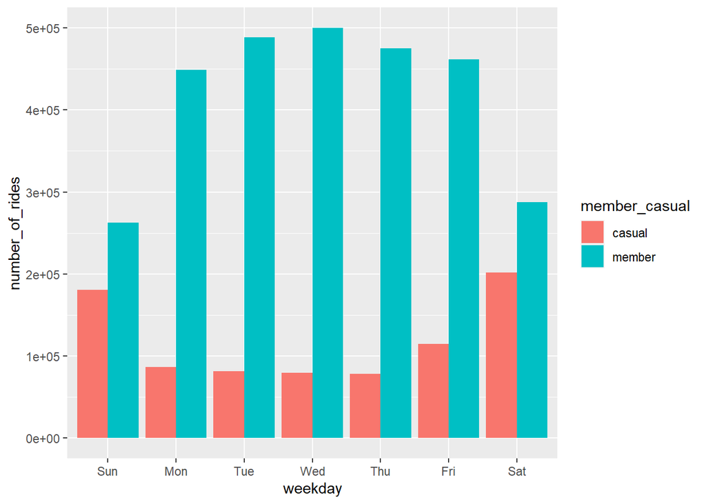

```r
Cyclistic_Data_v2 %>%
    mutate(weekday = wday(started_at, label = TRUE)) %>%
  group_by(member_casual, weekday) %>%
  summarise(number_of_rides = n()
  ,average_duration = mean(ride_length)) %>%
  arrange(member_casual, weekday)   %>%
  ggplot(aes(x = weekday, y = number_of_rides, fill = member_casual)) +
  geom_col(position = "dodge")
```

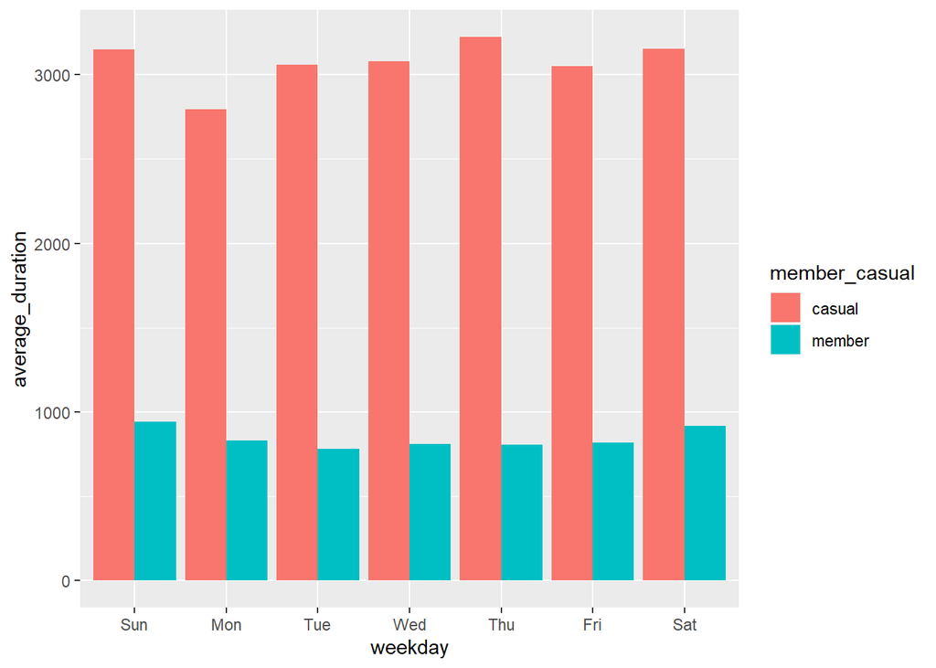

```r
Cyclistic_Data_v2 %>%
  mutate(weekday = wday(started_at, label = TRUE)) %>%
  group_by(member_casual, weekday) %>%
  summarise(number_of_rides = n()
            ,average_duration = mean(ride_length)) %>%
  arrange(member_casual, weekday)  %>%
  ggplot(aes(x = weekday, y = average_duration, fill = member_casual)) +
  geom_col(position = "dodge")
```

### Exporting summary file for further analysis

```r
Cyclistic_Data_Count <- aggregate(Cyclistic_Data_v2$ride_length ~ Cyclistic_Data_v2$member_casual + Cyclistic_Data_v2$day_of_week, FUN = mean)
write.csv(Cyclistic_Data_Count, file = "../avg_ride_length.csv")
write.csv(Cyclistic_Data_v2, file = "../cyclistic_cleaned_data.csv")
```